# Carteira de Mínima Variância usando R

# 4 Backtesting

A história não se repete (EVE, 1933) (leia, é curto). Ainda assim, vamos comparar como os nossos construtos se comportariam de fevereiro a outubro em conjunto com outros benchmarks, como o índice Bovespa e a própria carteira do meu amigo.

```r
# dados do ibovespa
suppressWarnings(getSymbols("^BVSP", from = "2020-02-02", to ="2020-10-31", warnings = FALSE))
```

```
[1] "^BVSP"
```

```r
# gerando resultados da carteira de dois ativos

alpha <- min_var_1(returns)
data_two <- returns %>%
  mutate(weighted = 1 + alpha * PSSA3.SA + (1-alpha) * ITUB3.SA,
         result = cumprod(weighted)-1) %>%
  select(date, result)

# gerando resultados da carteira de 10 ativos com a opção de se operar vendido
weight_vector <- min_var_2(data)
data_short <- data %>%
  mutate(weighted = pmap(data[, - 1], ~c(...)) %>%
           map_dbl(function(x) 1 + (x %*% t(weight_vector))),
         result = cumprod(weighted)-1
         ) %>%
  select(date, result)

data_no_short <-  data %>%
  mutate(weighted = pmap(data[, - 1], ~c(...)) %>%
           map_dbl(function(x) 1 + (x %*% (weights))),
         result = cumprod(weighted)-1
         ) %>%
  select(date, result)
# carteira do nosso amigo

more_weights <- c(0.1041, 0.2091, 0.1291, 0.1043, 0.726, 0.763, .449, 0.2371, 0.225)
data_friend <- data %>%
  mutate(weighted = pmap(data[, - 1], ~c(...)) %>%
           map_dbl(function(x) 1 + (x %*% (more_weights))),
         result = cumprod(weighted)-1
         ) %>%
  select(date, result)

# gerando os resultados do ibov

data_bvsp <- dailyReturn(BVSP) %>%
  tidy %>%
  mutate(result = cumprod(1 + value) - 1) %>%
  select(date = index, result)
```

```
missing values removed from data
```

```r
# criando tabela com todos os ret

final <- reduce(list(data_two, data_short, data_no_short, data_friend, data_bvsp), bind_cols) %>%
  select(-starts_with("date"), date...1) %>%
  set_names(., nm = c("amigo", "vendido", "sem", "friend", "bvsp", "date")) %>%
  pivot_longer(cols = -date, names_to = "series")
```

[output not shown]

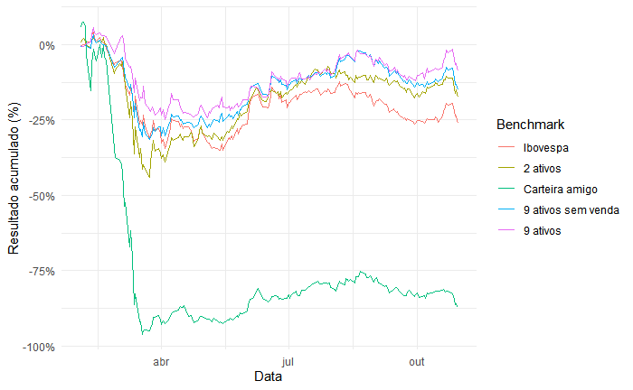

```r
final %>%
  ggplot(aes(x = date)) +
  geom_line(aes(y = value, color = series)) +
  scale_y_continuous(labels = scales::percent) +
  scale_color_discrete(name = "Benchmark", labels = c("Ibovespa", "2 ativos", "Carteira amigo", "9 ativos sem venda", "9 ativos")) +
  labs(y = "Resultado acumulado (%)",
       x = "Data")
```

Todas as carteiras performaram bastante mal durante o período. A carteira que teve menos perdas foi a que permitia que o gestor operasse vendido.

# 5 Limitações, extensões e observações

- Eu não mencionei isso ao longo do trabalho, mas o portfólio de mínima variância presume preços normalmente distribuídos. Ver QIAN; SORENSEN; HUA (2007, p. 24).
- É possível construir intervalos de confiança para os pesos usando algum método de reamostragem. É um processo bastante trabalhoso e pode ser tema de um próximo relatório como esse.
- Essa definitivamente não é uma sugestão, indicação ou qualquer coisa do tipo.

# 6 Referências

EVE, A. S. Does History Repeat Itself? **Nature**, v. 132, n. 3322, p. 30–30, jul. 1933.

JAMES, G. et al. **An Introduction to Statistical Learning**. [s.l.] Springer-Verlag GmbH, 2017.

MARKOWITZ, H. Portfolio Selection. **The Journal of Finance**, v. 7, n. 1, p. 77, mar. 1952.

QIAN, E. E.; SORENSEN, E. H.; HUA, R. H. **Quantitative Equity Portfolio Management: Modern Techniques and Applications**. [s.l.] CRC PR INC, 2007.

RUPPERT, D.; MATTESON, D. S. **Statistics and Data Analysis for Financial Engineering**. [s.l.] Springer New York, 2015.

[^1]: Se você vir algum erro, tiver alguma dúvida ou quiser discutir alguma ideia interessante não hesite em me mandar um e-mail: jclmntn@gmail.com
[^2]: Ou portfólio, é você quem manda. Daqui por diante vou usar só carteira!